# MM03_B10705016_顧寬証

$$\text{Management Mathematics}$$$$\text{Assignment 3}$$

```python
import numpy as np
import pandas as pd
import seaborn
```

## $\text{1. (70%) Cosine Similarity}$

$\text{(a) (10%) As in the above linkage, we generate six sentences are:}$

- $\text{A = “I love Management Mathematics”}$
- $\text{B = “I hate Management Mathematics”}$
- $\text{C = “I love Operations Research”}$
- $\text{D = “I hate Operations Research”}$
- $\text{E = “I love Manufacturing Data Science”}$
- $\text{F = “I hate Manufacturing Data Science”}$

```python
A = "I love Management Mathematics"
B = "I hate Management Mathematics"
C = "I love Operations Research"
D = "I hate Operations Research"
E = "I love Manufacturing Data Science"
F = "I hate Manufacturing Data Science"
```

$\text{(b) (10%) Based on the data in (a), get the list of words in each sentence by calling the split() in strings, and convert the sentence into lowercase by using lower(). Show the results.}$

```python
sentences = [A, B, C, D, E, F]
sentences = list(map(lambda s: s.lower(), sentences))
sentences = list(map(lambda s: s.split(), sentences))
N: int = len(sentences)
sentences
```

```
[['i', 'love', 'management', 'mathematics'],
 ['i', 'hate', 'management', 'mathematics'],
 ['i', 'love', 'operations', 'research'],
 ['i', 'hate', 'operations', 'research'],
 ['i', 'love', 'manufacturing', 'data', 'science'],
 ['i', 'hate', 'manufacturing', 'data', 'science']]
```

$\text{(c) (10%) Use the set class to identify the dimensionality of the feature space and print all vocabulary}$

$\text{Let }\mathbf F\text{ the feature space.}$

$$\mathbf F = \bigcup\limits_{i=1}^{6}\mathbf f_i$$

$\text{where }\mathbf f_i\text{ are the feature vectors of the generated sentences.}$

```python
from functools import reduce
vocab = reduce(lambda f1, f2: f1 | f2, map(set, sentences))
vocab
```

```
{'data',
 'hate',
 'i',
 'love',
 'management',
 'manufacturing',
 'mathematics',
 'operations',
 'research',
 'science'}
```

$\text{(d) (10%) To build the one-to-one mapping between features and IDs in the feature space.}$ $\text{We use the list() to convert the vocabulary into unique features.}$

```python
vocab = list(vocab)
vocab
```

```
['operations',
 'data',
 'i',
 'science',
 'love',
 'manufacturing',
 'mathematics',
 'hate',
 'research',
 'management']
```

$\text{It takes only }O(n\log n)\text{ time to make amortized }O(1)\text{ quries of index possible}$ $\text{by building a dictionary mapping the features to their indices.}$

```python
feat_to_idx = {s: i for i, s in enumerate(vocab)}
feat_to_idx
```

```
{'operations': 0,
 'data': 1,
 'i': 2,
 'science': 3,
 'love': 4,
 'manufacturing': 5,
 'mathematics': 6,
 'hate': 7,
 'research': 8,
 'management': 9}
```

```python
feat_vecs = np.array([np.zeros(len(vocab), dtype=float) for _ in range(N)])
feat_vecs
```

```
array([[0., 0., 0., 0., 0., 0., 0., 0., 0., 0.],
       [0., 0., 0., 0., 0., 0., 0., 0., 0., 0.],
       [0., 0., 0., 0., 0., 0., 0., 0., 0., 0.],
       [0., 0., 0., 0., 0., 0., 0., 0., 0., 0.],
       [0., 0., 0., 0., 0., 0., 0., 0., 0., 0.],
       [0., 0., 0., 0., 0., 0., 0., 0., 0., 0.]])
```

$\text{(e) (10%) Declare six 1D-arrays for the six sentences and build each word vector by increasing}$ $\text{the corresponding feature value (Hint: that is to build vA, vB, vC, vD, vE, and vF).}$

$\text{Define a function that explains what a feature vector.}$

```python
def feat_vec_repr(fv: np.array) -> str:
    components = []
    for i in range(fv.shape[0]):
        if fv[i] > 0:
            components.append(f'{vocab[i]} * {fv[i]}')
    return ' + '.join(components)
```

$\text{Build the feature vectors.}$

```python
for i in range(N):
    for w in sentences[i]:
        feat_vecs[i][feat_to_idx[w]] += 1
```

$\text{Check if the feature vectors were built correctly}.$

```python
list(zip(sentences, list(map(feat_vec_repr, feat_vecs))))
```

```
[(['i', 'love', 'management', 'mathematics'],
  'i * 1.0 + love * 1.0 + mathematics * 1.0 + management * 1.0'),
 (['i', 'hate', 'management', 'mathematics'],
  'i * 1.0 + mathematics * 1.0 + hate * 1.0 + management * 1.0'),
 (['i', 'love', 'operations', 'research'],
  'operations * 1.0 + i * 1.0 + love * 1.0 + research * 1.0'),
 (['i', 'hate', 'operations', 'research'],
  'operations * 1.0 + i * 1.0 + hate * 1.0 + research * 1.0'),
 (['i', 'love', 'manufacturing', 'data', 'science'],
  'data * 1.0 + i * 1.0 + science * 1.0 + love * 1.0 + manufacturing * 1.0'),
 (['i', 'hate', 'manufacturing', 'data', 'science'],
  'data * 1.0 + i * 1.0 + science * 1.0 + manufacturing * 1.0 + hate * 1.0')]
```

$\text{Seems great! We can move on to the next part.}$

$\text{(f) (10%) Compute the cosine similarity between two vectors, and show a 6x6 matrix including}$ $\text{these similarity values (Hint: the diagonal elements should be 1).}$

```python
sim_mat = np.array([np.ones(N, dtype=float)] * N)
sim_mat
```

```
array([[1., 1., 1., 1., 1., 1.],
       [1., 1., 1., 1., 1., 1.],
       [1., 1., 1., 1., 1., 1.],
       [1., 1., 1., 1., 1., 1.],
       [1., 1., 1., 1., 1., 1.],
       [1., 1., 1., 1., 1., 1.]])
```

$$\text{Cosine Simliarity of }\mathbf A\text{ and }\mathbf B={\mathbf A\cdot\mathbf B\over \left\lVert \mathbf A \right\rVert \left\lVert \mathbf B \right\rVert}$$

```python
def cosine_similarity(fv1: np.array, fv2: np.array) -> float:
    assert(fv1.shape[0] == fv2.shape[0])
    return fv1.dot(fv2) / (np.linalg.norm(fv1) * np.linalg.norm(fv2))
```

```python
sim_mat = [[cosine_similarity(fv1, fv2) for fv1 in feat_vecs] for fv2 in feat_vecs]
sim_mat = np.array(list(map(np.array, sim_mat)))

sim_mat
```

```
array([[1.       , 0.75     , 0.5      , 0.25     , 0.4472136, 0.2236068],
       [0.75     , 1.       , 0.25     , 0.5      , 0.2236068, 0.4472136],
       [0.5      , 0.25     , 1.       , 0.75     , 0.4472136, 0.2236068],
       [0.25     , 0.5      , 0.75     , 1.       , 0.2236068, 0.4472136],
       [0.4472136, 0.2236068, 0.4472136, 0.2236068, 1.       , 0.8      ],
       [0.2236068, 0.4472136, 0.2236068, 0.4472136, 0.8      , 1.       ]])
```

$\text{(g) (10%) Based on the similarity matrix, what’s the results you draw?}$

$\text{Let's visalize the feature vectors with a heat map.}$

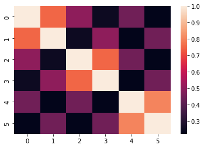

```python
seaborn.heatmap(sim_mat)
```

## $\text{2. (30%) Information Retrieval}$

$\text{(a) (10%) Build up the following matrix for preparing information retrieval, and convert all}$ $\text{column vectors into unit vectors as matrix 𝐐.}$

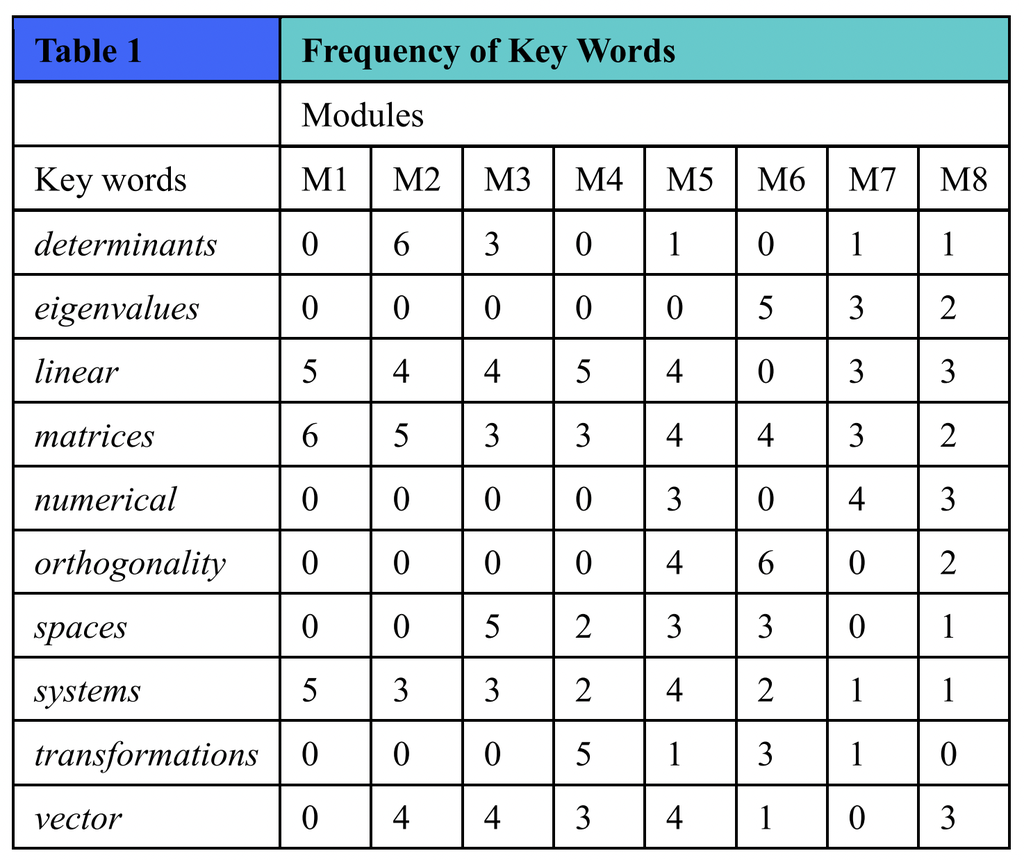

```python
cols = [
    [0, 0, 5, 6, 0, 0, 0, 5, 0, 0],
    [6, 0, 4, 5, 0, 0, 0, 3, 0, 4],
    [3, 0, 4, 3, 0, 0, 5, 3, 0, 4],
    [0, 0, 5, 3, 0, 0, 2, 2, 5, 3],
    [1, 0, 4, 4, 3, 4, 3, 4, 1, 4],
    [0, 5, 0, 4, 0, 6, 3, 2, 3, 1],
    [1, 3, 3, 3, 4, 0, 0, 1, 1, 0],
    [1, 2, 3, 2, 3, 2, 1, 1, 0, 3]
]
cols
```

```
[[0, 0, 5, 6, 0, 0, 0, 5, 0, 0],
 [6, 0, 4, 5, 0, 0, 0, 3, 0, 4],
 [3, 0, 4, 3, 0, 0, 5, 3, 0, 4],
 [0, 0, 5, 3, 0, 0, 2, 2, 5, 3],
 [1, 0, 4, 4, 3, 4, 3, 4, 1, 4],
 [0, 5, 0, 4, 0, 6, 3, 2, 3, 1],
 [1, 3, 3, 3, 4, 0, 0, 1, 1, 0],
 [1, 2, 3, 2, 3, 2, 1, 1, 0, 3]]
```

```python
def unit_vec(vec: list[float]) -> list[float]:
    sq_sum = sum(map(lambda x: x ** 2, vec))
    norm = sq_sum ** .5
    assert(norm != 0)
    return list(map(lambda x: x / norm, vec))
```

```python
cols: list[list[float]] = [unit_vec(col) for col in cols]
cols
```

```
[[0.0,
  0.0,
  0.539163866017192,
  0.6469966392206304,
  0.0,
  0.0,
  0.0,
  0.539163866017192,
  0.0,
  0.0],
 [0.5940885257860046,
  0.0,
  0.39605901719066977,
  0.4950737714883372,
  0.0,
  0.0,
  0.0,
  0.2970442628930023,
  0.0,
  0.39605901719066977],
 [0.3273268353539886,
  0.0,
  0.4364357804719848,
  0.3273268353539886,
  0.0,
  0.0,
  0.545544725589981,
  0.3273268353539886,
  0.0,
  0.4364357804719848],
 [0.0,
  0.0,
  0.5735393346764044,
  0.3441236008058426,
  0.0,
  0.0,
  0.22941573387056174,
  0.22941573387056174,
  0.5735393346764044,
  0.3441236008058426],
 [0.1, 0.0, 0.4, 0.4, 0.3, 0.4, 0.3, 0.4, 0.1, 0.4],
 [0.0, 0.5, 0.0, 0.4, 0.0, 0.6, 0.3, 0.2, 0.3, 0.1],
 [0.14744195615489714,
  0.4423258684646914,
  0.4423258684646914,
  0.4423258684646914,
  0.5897678246195885,
  0.0,
  0.0,
  0.14744195615489714,
  0.14744195615489714,
  0.0],
 [0.1543033499620919,
  0.3086066999241838,
  0.4629100498862757,
  0.3086066999241838,
  0.4629100498862757,
  0.3086066999241838,
  0.1543033499620919,
  0.1543033499620919,
  0.0,
  0.4629100498862757]]
```

```python
Q: np.array = np.array([np.array(col) for col in cols]).T
Q
```

```
array([[0.        , 0.59408853, 0.32732684, 0.        , 0.1       ,
        0.        , 0.14744196, 0.15430335],
       [0.        , 0.        , 0.        , 0.        , 0.        ,
        0.5       , 0.44232587, 0.3086067 ],
       [0.53916387, 0.39605902, 0.43643578, 0.57353933, 0.4       ,
        0.        , 0.44232587, 0.46291005],
       [0.64699664, 0.49507377, 0.32732684, 0.3441236 , 0.4       ,
        0.4       , 0.44232587, 0.3086067 ],
       [0.        , 0.        , 0.        , 0.        , 0.3       ,
        0.        , 0.58976782, 0.46291005],
       [0.        , 0.        , 0.        , 0.        , 0.4       ,
        0.6       , 0.        , 0.3086067 ],
       [0.        , 0.        , 0.54554473, 0.22941573, 0.3       ,
        0.3       , 0.        , 0.15430335],
       [0.53916387, 0.29704426, 0.32732684, 0.22941573, 0.4       ,
        0.2       , 0.14744196, 0.15430335],
       [0.        , 0.        , 0.        , 0.57353933, 0.1       ,
        0.3       , 0.14744196, 0.        ],
       [0.        , 0.39605902, 0.43643578, 0.3441236 , 0.4       ,
        0.1       , 0.        , 0.46291005]])
```

```python
Q = pd.DataFrame(Q)
Q.index = [
    'determinants',
    'eigenvalues',
    'linear',
    'matrices',
    'numerical',
    'orthogonality',
    'spaces',
    'systems',
    'transformations',
    'vector'
]
Q.columns = [f'M{i+1}' for i in range(8)]
Q
```

|  | M1 | M2 | M3 | M4 | M5 | M6 | M7 | M8 |
| --- | --- | --- | --- | --- | --- | --- | --- | --- |
| determinants | 0.000000 | 0.594089 | 0.327327 | 0.000000 | 0.1 | 0.0 | 0.147442 | 0.154303 |
| eigenvalues | 0.000000 | 0.000000 | 0.000000 | 0.000000 | 0.0 | 0.5 | 0.442326 | 0.308607 |
| linear | 0.539164 | 0.396059 | 0.436436 | 0.573539 | 0.4 | 0.0 | 0.442326 | 0.462910 |
| matrices | 0.646997 | 0.495074 | 0.327327 | 0.344124 | 0.4 | 0.4 | 0.442326 | 0.308607 |
| numerical | 0.000000 | 0.000000 | 0.000000 | 0.000000 | 0.3 | 0.0 | 0.589768 | 0.462910 |
| orthogonality | 0.000000 | 0.000000 | 0.000000 | 0.000000 | 0.4 | 0.6 | 0.000000 | 0.308607 |
| spaces | 0.000000 | 0.000000 | 0.545545 | 0.229416 | 0.3 | 0.3 | 0.000000 | 0.154303 |
| systems | 0.539164 | 0.297044 | 0.327327 | 0.229416 | 0.4 | 0.2 | 0.147442 | 0.154303 |
| transformations | 0.000000 | 0.000000 | 0.000000 | 0.573539 | 0.1 | 0.3 | 0.147442 | 0.000000 |
| vector | 0.000000 | 0.396059 | 0.436436 | 0.344124 | 0.4 | 0.1 | 0.000000 | 0.462910 |

$\text{(b) (10%) To do a search for the key words } determinants, matrices,\text{ and }systems.\text{ Form a unit}$ $\text{search vector }\mathbf x\text{ whose entries are all 0 except for the three rows corresponding to the search rows.}$

$\text{Form a unit search vector }\mathbf x\text{.}$

```python
keywords = ['determinants', 'matrices', 'systems']
search_vec = [1 if kw in keywords else 0 for kw in Q.index]
search_vec
unit_search_vec = unit_vec(search_vec)
x: np.array = np.array(unit_search_vec)
x
```

```
array([0.57735027, 0.        , 0.        , 0.57735027, 0.        ,
       0.        , 0.        , 0.57735027, 0.        , 0.        ])
```

$\text{(c) (10%) Calculate the cosine similarity }\mathbf y=\mathbf Q^T\mathbf x\text{, and rank the modules.}$

$\text{Obtain the vector }\mathbf y.$

```python
y = Q.T.dot(x)
```

$\text{Rank the modules by their cosine similarity values.}$

```python
y.sort_values(ascending=False)
```

```
M2    0.800327
M1    0.684830
M3    0.566947
M5    0.519615
M7    0.425628
M8    0.356348
M6    0.346410
M4    0.331133
dtype: float64
```

$\text{Module }M2\text{ is the module that best match the search criteria}.$

$\text{Modules that match the search criteria following }M2\text{ are }M1, M3, M5, M7, M8, M6\text{ and }M4\text{, ordered in similarity.}$